# Kmeans CSV

```python
from __future__ import division
%matplotlib inline
import pandas as pd
import numpy as np
import matplotlib.pyplot as plt
from sklearn import cluster, datasets
from sklearn.cluster import KMeans
df = pd.read_csv("../data/SFPD_Incidents_-_from_1_January_2003.csv") #load csv
```

**Visualize the prostitution data (e.g. by plotting it on a map)**

[figure not shown]

```python
import geoplotlib
from geoplotlib.utils import read_csv, BoundingBox, DataAccessObject

df_prostitution = df[df.Category == 'PROSTITUTION']
df_prostitution_cols = df_prostitution[['X', 'Y']]
df_prostitution_cols = df_prostitution_cols[df.Y != 90.0] #remove crimes with no location

max_lon = df_prostitution_cols.X.max()
min_lon = df_prostitution_cols.X.min()
max_lat = df_prostitution_cols.Y.max()
min_lat = df_prostitution_cols.Y.min()

#strucure prostitution data into format for geoplotlib, convert X df X column of longitudes to list
#convert X df Y column of latitiudes to list
geo_data_for_plotting_prostitution = {"lat": df_prostitution_cols['Y'].tolist(),
                         "lon": df_prostitution_cols['X'].tolist()}

#define bounds for map to display
bbox = BoundingBox(max_lat, min_lon, min_lat, max_lon)

## PROSTITUTION map ##
geoplotlib.dot(geo_data_for_plotting_prostitution) #Create kernal density map
geoplotlib.set_bbox(bbox)
geoplotlib.inline()
```

**> * Train models of $K = 2,\ldots,10$ on the prostitution data.**

```python
from sklearn import cluster, datasets
from sklearn.cluster import KMeans

data = df_prostitution_cols.values.tolist()

#Loop through k values and train k means on prostitution data
k_means = [KMeans(k).fit(data) for k in range(2,11)]
```

**Explore how the total squared error changes as a function of $K$ and identify what you think is the right number of clusers based on the knee-point in the squared error plot.**

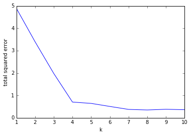

```python
from __future__ import division
#from linear_algebra import squared_distance, vector_mean, distance
import math, random
import matplotlib.image as mpimg
import matplotlib.pyplot as plt

def scalar_multiply(c, v):
    return [c * v_i for v_i in v]

def vector_mean(vectors):
    """compute the vector whose i-th element is the mean of the
    i-th elements of the input vectors"""
    n = len(vectors)
    return scalar_multiply(1/n, vector_sum(vectors))

def squared_distance(v, w):
    return sum_of_squares(vector_subtract(v, w))

def vector_subtract(v, w):
    """subtracts two vectors componentwise"""
    return [v_i - w_i for v_i, w_i in zip(v,w)]

def distance(v, w):
    return math.sqrt(squared_distance(v, w))

def sum_of_squares(v):
    """v_1 * v_1 + ... + v_n * v_n"""
    return dot(v, v)

def vector_add(v, w):
    """adds two vectors componentwise"""
    return [v_i + w_i for v_i, w_i in zip(v,w)]


def vector_sum(vectors):
    return reduce(vector_add, vectors)

def dot(v, w):
    """v_1 * w_1 + ... + v_n * w_n"""
    return sum(v_i * w_i for v_i, w_i in zip(v, w))

class KMeans:

    """performs k-means clustering"""

    def __init__(self, k):
        self.k = k          # number of clusters
        self.means = None   # means of clusters

    def classify(self, input):
        """return the index of the cluster closest to the input"""
        return min(range(self.k),
                   key=lambda i: squared_distance(input, self.means[i]))

    def train(self, inputs):

        self.means = random.sample(inputs, self.k)
        assignments = None

        while True:
            # Find new assignments
            new_assignments = map(self.classify, inputs)

            # If no assignments have changed, we're done.
            if assignments == new_assignments:
                return

            # Otherwise keep the new assignments,
            assignments = new_assignments

            for i in range(self.k):
                i_points = [p for p, a in zip(inputs, assignments) if a == i]
                # avoid divide-by-zero if i_points is empty
                if i_points:
                    self.means[i] = vector_mean(i_points)

def squared_clustering_errors(inputs, k):
    """finds the total squared error from k-means clustering the inputs"""
    clusterer = KMeans(k)
    clusterer.train(inputs)
    means = clusterer.means
    assignments = map(clusterer.classify, inputs)

    return sum(squared_distance(input,means[cluster])
               for input, cluster in zip(inputs, assignments))

def plot_squared_clustering_errors(plt):

    ks = range(1, 11)
    errors = [squared_clustering_errors(inputs, k) for k in ks]

    plt.plot(ks, errors)
    plt.xticks(ks)
    plt.xlabel("k")
    plt.ylabel("total squared error")
    plt.show()

#
# using clustering to recolor an image
#

def recolor_image(input_file, k=5):

    img = mpimg.imread(path_to_png_file)
    pixels = [pixel for row in img for pixel in row]
    clusterer = KMeans(k)
    clusterer.train(pixels) # this might take a while

    def recolor(pixel):
        cluster = clusterer.classify(pixel) # index of the closest cluster
        return clusterer.means[cluster]     # mean of the closest cluster

    new_img = [[recolor(pixel) for pixel in row]
               for row in img]

    plt.imshow(new_img)
    plt.axis('off')
    plt.show()

#
# hierarchical clustering
#

def is_leaf(cluster):
    """a cluster is a leaf if it has length 1"""
    return len(cluster) == 1

def get_children(cluster):
    """returns the two children of this cluster if it's a merged cluster;
    raises an exception if this is a leaf cluster"""
    if is_leaf(cluster):
        raise TypeError("a leaf cluster has no children")
    else:
        return cluster[1]

def get_values(cluster):
    """returns the value in this cluster (if it's a leaf cluster)
    or all the values in the leaf clusters below it (if it's not)"""
    if is_leaf(cluster):
        return cluster # is already a 1-tuple containing value
    else:
        return [value
                for child in get_children(cluster)
                for value in get_values(child)]

def cluster_distance(cluster1, cluster2, distance_agg=min):
    """finds the aggregate distance between elements of cluster1
    and elements of cluster2"""
    return distance_agg([distance(input1, input2)
                        for input1 in get_values(cluster1)
                        for input2 in get_values(cluster2)])

def get_merge_order(cluster):
    if is_leaf(cluster):
        return float('inf')
    else:
        return cluster[0] # merge_order is first element of 2-tuple

def bottom_up_cluster(inputs, distance_agg=min):
    # start with every input a leaf cluster / 1-tuple
    clusters = [(input,) for input in inputs]

    # as long as we have more than one cluster left...
    while len(clusters) > 1:
        # find the two closest clusters
        c1, c2 = min([(cluster1, cluster2)
                     for i, cluster1 in enumerate(clusters)
                     for cluster2 in clusters[:i]],
                     key=lambda (x, y): cluster_distance(x, y, distance_agg))

        # remove them from the list of clusters
        clusters = [c for c in clusters if c != c1 and c != c2]

        # merge them, using merge_order = # of clusters left
        merged_cluster = (len(clusters), [c1, c2])

        # and add their merge
        clusters.append(merged_cluster)

    # when there's only one cluster left, return it
    return clusters[0]

def generate_clusters(base_cluster, num_clusters):
    # start with a list with just the base cluster
    clusters = [base_cluster]

    # as long as we don't have enough clusters yet...
    while len(clusters) < num_clusters:
        # choose the last-merged of our clusters
        next_cluster = min(clusters, key=get_merge_order)
        # remove it from the list
        clusters = [c for c in clusters if c != next_cluster]
        # and add its children to the list (i.e., unmerge it)
        clusters.extend(get_children(next_cluster))

    # once we have enough clusters...
    return clusters

df_prostitution = df[df.Category == 'PROSTITUTION']
df_prostitution_cols = df_prostitution[['X', 'Y']]
df_prostitution_cols = df_prostitution_cols[df.Y != 90.0] #remove crimes with no location
inputs = df_prostitution_cols.values.tolist()

random.seed(0) # so you get the same results as me
plot_squared_clustering_errors(plt)
```

**And by the way: The fit only gets better when we add more means - why not keep adding more of them: Explain in your own words why it makes sense to stop around a knee-point.**

The total squared error only reduces slightly after k=4 and we don't want to over fit the data into clusters. For example if we had the same number of clusters as we do data points then the squared error would be 0 but then we wouldn't have useful clusters. We want to find the best fit clusters without fitting more than we need to.

**Explain why stability should help you find the right number of clusters.**

As with clustering there is no ultimately correct answer to the number of clusters often data points can be clustered in more than one way maybe using a horizontal or vertical slice will lead to acceptable clusters. What stability does is take this uncertainty away by saying that the correct number of clusters is when given any set of points generated in the same way clusters should form in the same way.

**Using Python, create a CVS/JSON file containing the data you wish to visualize. The datapoints you should use, is the same as for week 5, so it is all crimes with type = PROSTITUTION Note : Think carefully about how you can minimize the size of the file containing the data. My file is around 700KB. Why is the size of the file important?**

It's because load speed is important, all of the data is being loaded when the browser loads, so the larger the file the longer until the visualization loads. Leading it too long may mean users leave the page without ever seeing our awesome data visualizations if the file is too large.

```python
#get X and Y values for prostitution data and remove crimes with no location
df_prostitution = df[['X', 'Y']][(df.Category == 'PROSTITUTION') & (df.Y != 90.0)]

k_means_dict = {}
#train data with k clusters 2 - 6
for k in range(2,7):
    k_means_dict[str(k)] = KMeans(k).fit(df_prostitution.values.tolist())
```

```python
headings = ['X', 'Y', 'k', 'centroid']

locations_df = df_prostitution[['X', 'Y']]

#create dataframe of minimal data required
for k, k_means_groups in k_means_dict.iteritems():
    locations_df = df_prostitution[['X', 'Y']]

    locations_df['k'] = k_means_groups.labels_
    locations_df['centroid'] = [False for x in range(0, len(k_means_groups.labels_))]

    centroid_df = pd.DataFrame([], columns=headings)
    centroids = k_means_groups.cluster_centers_
    centroid_df['X'] = centroids[:, 0]
    centroid_df['Y'] = centroids[:, 1]
    centroid_df['k'] = range(0, int(k))
    centroid_df['centroid'] = [True for x in range(0, int(k))]

    all_df = locations_df.append(centroid_df, ignore_index=True)
    all_df.to_csv('..\data\\k'+ k +'.csv')
```